# Time_Series_Project_KAWA

Katarzyna Gołąb, Anna Wygoda, Wioletta Sudoł, Aneta Buszta

2026-01-17

# TASK 1

- Consider the monthly numbers of passengers (see below for file AKW-12.csv).
- Plot the spectral density estimator and discuss it. Try different weights (using Daniell kernels).
- Make numbers of passengers forecasts for each month of the first half of 2026.

```r
library(tseries)
library(astsa)
library(forecast)
```

## Working with data

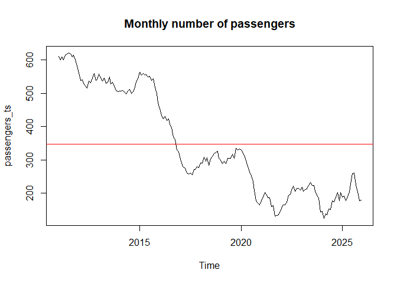

```r
library(readr)
AKW.12 <- read.csv("C:/Users/Public/AKW-12.csv")
View(AKW.12)

passengers<-AKW.12
passengers_ts<-ts(passengers$passengers, start = c(2011,1), frequency = 12)

plot(passengers_ts, main="Monthly number of passengers")
abline(h=mean(passengers_ts), col="red")
```

## Monthplot

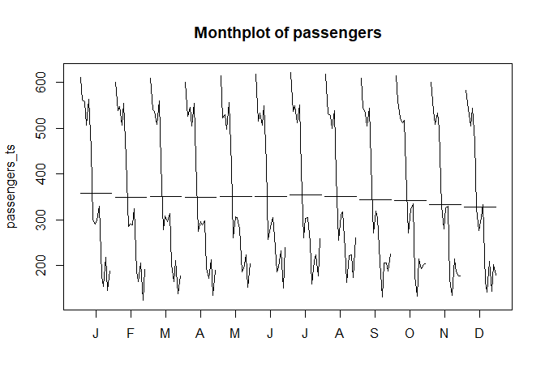

```r
monthplot(passengers_ts, main = "Monthplot of passengers") #checking if there is seasonality
```

The monthplot does not reveal a clear or stable monthly seasonal pattern, so there is no seasonality.

## ACF and PACF

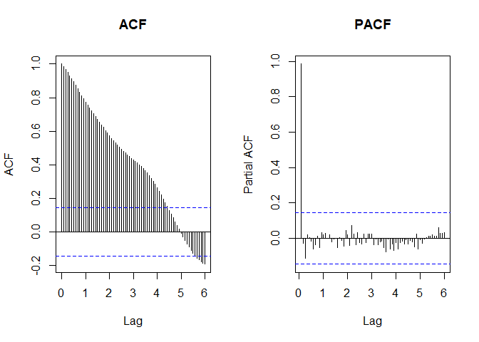

```r
par(mfrow = c(1,2))
acf(passengers_ts, lag.max=72, main="ACF")
pacf(passengers_ts, lag.max=72, main="PACF")
```

The ACF and PACF analysis indicates that the time series is non-stationary, because of persistent autocorrelation.

## Periodogram

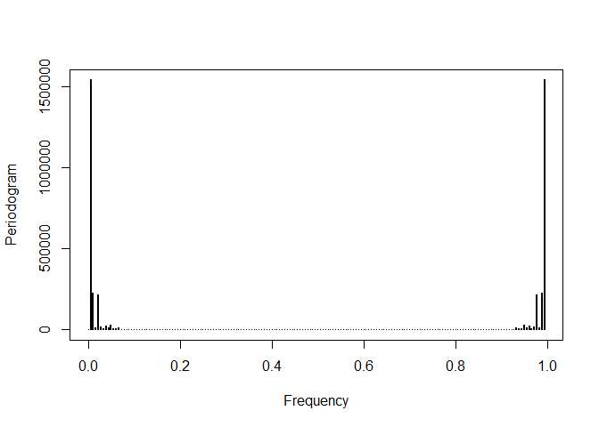

```r
n = length(passengers_ts)
Per= Mod(fft(passengers_ts-mean(passengers_ts)))^2/n
Freq = (1:n -1)/n
plot(Freq[1:n], Per[1:n], type='h', lwd=2, ylab="Periodogram",
     xlab="Frequency")
```

```r
nn=n/2
u = which.max(Per[1:nn])
uu = which.max(Per[1:nn][-u])
1/Freq[u]
```

```
## [1] 180
```

```r
1/Freq[uu]
```

```
## [1] 180
```

This behavior is typical for non-stationary time series. We observed no clear isolated peaks corresponding to stable periodic behavior. Therefore, the periodogram of the raw series does not provide reliable evidence of seasonal cycles and should be interpreted with caution.

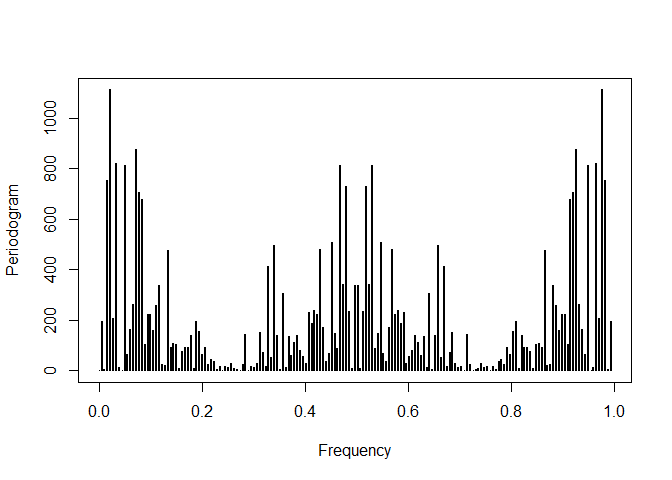

```r
d_passengers_ts<-diff(passengers_ts,1)
n = length(d_passengers_ts)
Per= Mod(fft(d_passengers_ts-mean(d_passengers_ts)))^2/n
Freq = (1:n -1)/n
plot(Freq[1:n], Per[1:n], type='h', lwd=2, ylab="Periodogram",
     xlab="Frequency")
```

```r
nn=n/2
u = which.max(Per[1:nn])
uu = which.max(Per[1:nn][-u])
1/Freq[u]
```

```
## [1] 44.75
```

```r
1/Freq[uu]
```

```
## [1] 14.91667
```

```r
y = cbind(1:nn, Freq[1:nn], 1/Freq[1:nn],Per[1:nn]); y[order(y[,4],decreasing = TRUE),]
```

```
##       [,1]        [,2]       [,3]         [,4]
##  [1,]    5 0.022346369  44.750000 1.112247e+03
##  [2,]   14 0.072625698  13.769231 8.761397e+02
##  [3,]    7 0.033519553  29.833333 8.216574e+02
##  [4,]   10 0.050279330  19.888889 8.133827e+02
##  [5,]   85 0.469273743   2.130952 8.131620e+02
##  [6,]    4 0.016759777  59.666667 7.535923e+02
##  [7,]   87 0.480446927   2.081395 7.283509e+02
##  [8,]   15 0.078212291  12.785714 7.072192e+02
##  [9,]   16 0.083798883  11.933333 6.797897e+02
## [10,]   82 0.452513966   2.209877 5.068672e+02
## [11,]   62 0.340782123   2.934426 4.948795e+02
## [12,]   78 0.430167598   2.324675 4.817130e+02
## [13,]   25 0.134078212   7.458333 4.763052e+02
## [14,]   60 0.329608939   3.033898 4.144544e+02
```

[output cut: 75 more lines]

### Daniell kernel

```r
par(mfrow=c(3,2))
for ( i in 1:6 )
{
  mvspec(d_passengers_ts, kernel=kernel("daniell",c(1,i)))
}
```

```
## Bandwidth: 0.284 | Degrees of Freedom: 8.48 | split taper: 0%
```

```
## Bandwidth: 0.405 | Degrees of Freedom: 12.09 | split taper: 0%
```

```
## Bandwidth: 0.535 | Degrees of Freedom: 15.95 | split taper: 0%
```

```
## Bandwidth: 0.666 | Degrees of Freedom: 19.86 | split taper: 0%
```

```
## Bandwidth: 0.798 | Degrees of Freedom: 23.8 | split taper: 0%
```

```
## Bandwidth: 0.93 | Degrees of Freedom: 27.75 | split taper: 0%
```

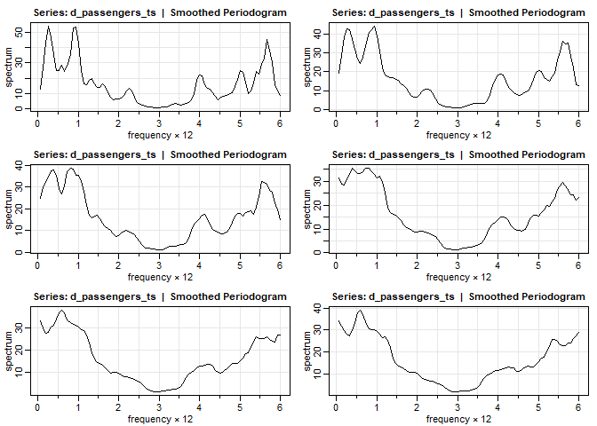

Among the spectral density estimates obtained using Daniell kernels, the plot from the third row was chosen by us as it provides a moderate level of smoothing.

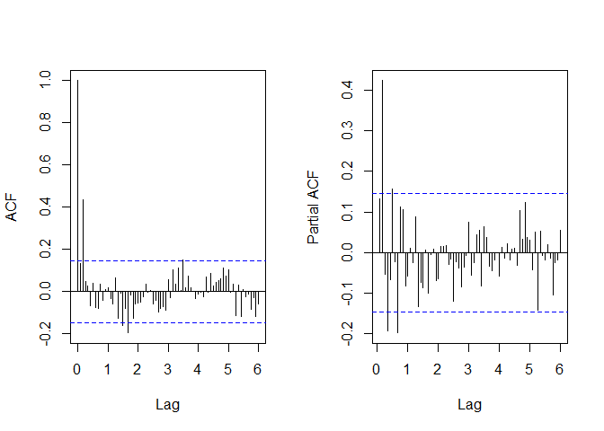

```r
LM<-72
par(mfrow=c(1,2))
acf(d_passengers_ts, lag.max = LM, main="")
pacf(d_passengers_ts, lag.max = LM, main="")
```

The ACF and PACF plots of the first-differenced series show a substantial reduction in long-range dependence compared to the original series. Autocorrelations decay rapidly and mostly lie within the confidence bounds, indicating that differencing has effectively removed the non-stationarity associated with the trend. Overall, the differenced series appears approximately stationary and we can proceed to forecasting.

## Fitting models

```r
mA<-sarima(passengers_ts,0,1,1,0,0,0) # Sarima(0,1,1)(0,0,0)[12]
```

```
## <><><><><><><><><><><><><><>
##
## Coefficients:
##     Estimate     SE t.value p.value
## ma1   0.0838 0.0544  1.5413   0.125
##
## sigma^2 estimated as 196.4354 on 178 degrees of freedom
##
## AIC = 8.140596  AICc = 8.140723  BIC = 8.17621
##
```

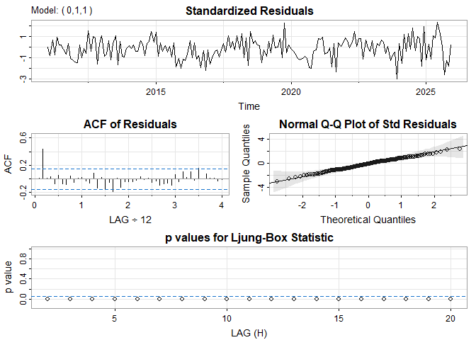

```r
mA_1<-sarima(passengers_ts,0,1,2,0,0,0) # Sarima(0,1,2)(0,0,0)[12]
```

```
## <><><><><><><><><><><><><><>
##
## Coefficients:
##     Estimate     SE t.value p.value
## ma1   0.0356 0.0534  0.6673  0.5055
## ma2   0.6641 0.0643 10.3286  0.0000
##
## sigma^2 estimated as 142.4514 on 177 degrees of freedom
##
## AIC = 7.8369  AICc = 7.837281  BIC = 7.89032
##
```

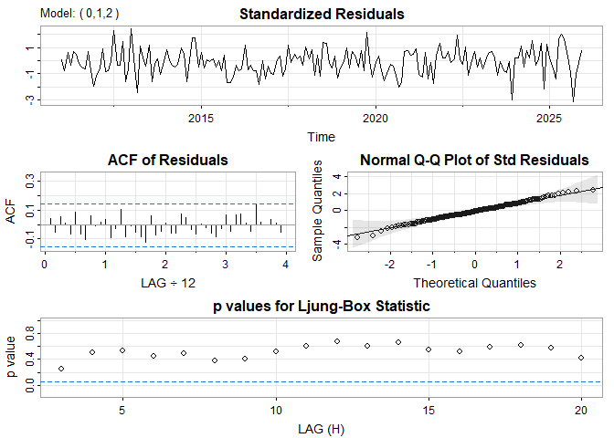

```r
mA_2<-sarima(passengers_ts,1,1,2,0,0,0) # Sarima(1,1,2)(0,0,0)[12]
```

```
## <><><><><><><><><><><><><><>
##
## Coefficients:
##     Estimate     SE t.value p.value
## ar1   0.1102 0.1038  1.0615  0.2899
## ma1  -0.0194 0.0734 -0.2643  0.7919
## ma2   0.6609 0.0662  9.9775  0.0000
##
## sigma^2 estimated as 141.5625 on 176 degrees of freedom
##
## AIC = 7.841859  AICc = 7.842625  BIC = 7.913086
##
```

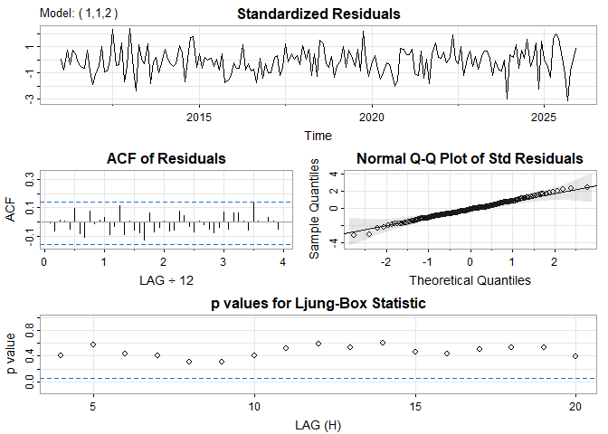

```r
mA_3<-sarima(passengers_ts,0,1,3,0,0,0) # Sarima(0,1,3)(0,0,0)[12]
```

```
## <><><><><><><><><><><><><><>
##
## Coefficients:
##     Estimate     SE t.value p.value
## ma1   0.1042 0.0782  1.3325  0.1844
## ma2   0.6669 0.0648 10.2933  0.0000
## ma3   0.0911 0.0770  1.1842  0.2379
##
## sigma^2 estimated as 141.3407 on 176 degrees of freedom
##
## AIC = 7.840354  AICc = 7.84112  BIC = 7.911581
##
```

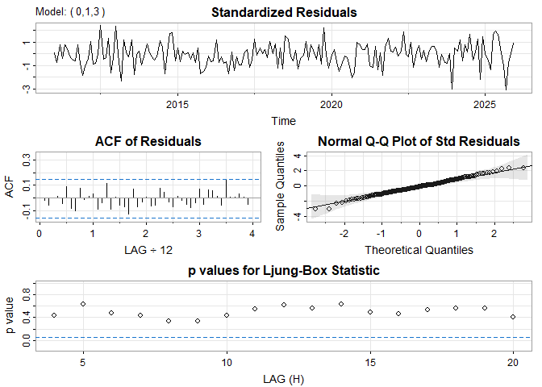

Based on the analysis of ACF and PACF plots, spectral estimates, residual diagnostics and the Ljung–Box test, the ARIMA(0,1,2) model was identified as the most appropriate for the data. This model effectively removes autocorrelation from the residuals, which behave approximately as white noise, and the Ljung–Box test does not indicate significant remaining dependence. Higher-order models do not provide a meaningful improvement in fit, therefore we selected ARIMA(0,1,2) as the final model for forecasting.

```r
auto.arima(passengers_ts)
```

```
## Series: passengers_ts
## ARIMA(0,1,2) with drift
##
## Coefficients:
##          ma1     ma2    drift
##       0.0320  0.6573  -2.3583
## s.e.  0.0534  0.0658   1.4903
##
## sigma^2 = 142.9:  log likelihood = -697.17
## AIC=1402.34   AICc=1402.57   BIC=1415.09
```

We use the automatic function as a supporting tool for automatic ARIMA model selection based on information criteria. It allows an objective comparison of a wide range of candidate models and identifies a model that balances goodness of fit and model complexity

## Forecasting

```r
par(mfrow=c(1,1))
modelll<-sarima(passengers_ts,0,1,2,0,0,0)
```

```
## <><><><><><><><><><><><><><>
##
## Coefficients:
##     Estimate     SE t.value p.value
## ma1   0.0356 0.0534  0.6673  0.5055
## ma2   0.6641 0.0643 10.3286  0.0000
##
## sigma^2 estimated as 142.4514 on 177 degrees of freedom
##
## AIC = 7.8369  AICc = 7.837281  BIC = 7.89032
##
```

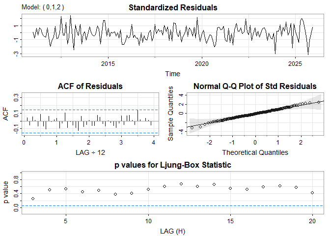

```r
forecast_result<-sarima.for(passengers_ts,n.ahead=6,0,1,2,0,0,0)
```

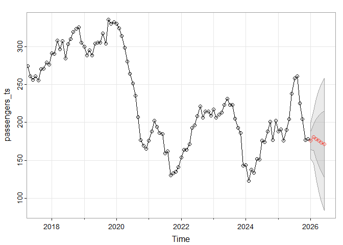

The plot shows the forecast of the number of passengers for the first half of 2026 obtained using the ARIMA(0,1,2) model. The point forecasts suggest a stabilization of passenger numbers in the short-term horizon, with no pronounced seasonal fluctuations. The shaded areas represent prediction intervals, which widen as the forecast horizon increases, reflecting growing uncertainty. These results are consistent with the earlier analysis.

```r
forecast_df <- data.frame(
  Month = c("Jan", "Feb", "Mar", "Apr", "May", "Jun"),
  Year = rep(2026, 6),
  Forecast = forecast_result$pred,
  Lower_CI = forecast_result$pred - 2*forecast_result$se, #?
  Upper_CI = forecast_result$pred + 2*forecast_result$se  #?
)
```

```r
print(forecast_df)
```

```
##   Month Year Forecast  Lower_CI Upper_CI
## 1   Jan 2026 175.8239 152.11524 199.5325
## 2   Feb 2026 180.6066 146.53701 214.6763
## 3   Mar 2026 178.2484 125.66611 230.8306
## 4   Apr 2026 175.8901 109.79132 241.9889
## 5   May 2026 173.5318  96.24534 250.8183
## 6   Jun 2026 171.1736  84.12555 258.2216
```

We present in the table above the predicted numbers of passengers from January to June 2026.

# TASK 2

- Consider the Aneta’s time series from Lab 1 task 4.2 (i.e Average Monthly surface temperature, 1940-2024)
- Make all necessary transformations to get a stationary time series (noise).
- If possible, choose the ARMA (p, q) model for stationary noise.

```r
library(astsa)
```

## Loading data

This Dataset contains details of Average Monthly surface temperature (1940-2024). We decided to choose Poland. Values of this time series are from the 1st of January 1940 to the 15th of December 2024 - 1020 values in total.

```r
library(readr)
temp <- read_csv("C:/Users/Public/average-monthly-surface-temperature.csv")
```

```r
temp_pl <- subset(temp, Entity == "Poland")
```

```r
temp_ts <- ts(temp_pl[,5], start = c(1940,1), frequency = 12)
```

## Working with data

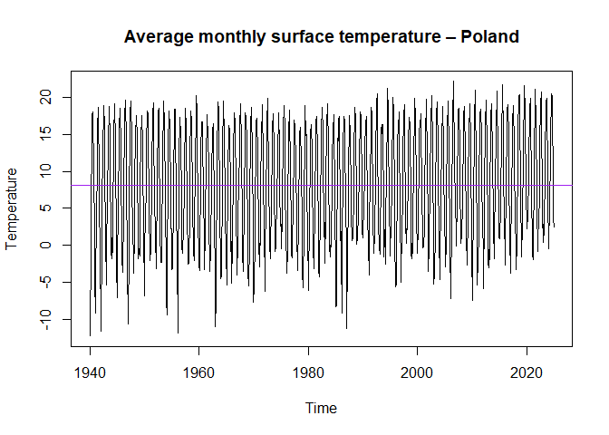

```r
plot(temp_ts, main = "Average monthly surface temperature – Poland", ylab = "Temperature")
abline(h = mean(temp_ts), col = "purple")
```

We can observe some trend and seasonality.